# R Notebook

# Time Series Analysis on Microsoft Stock

```r
MSFT_day=read.csv("https://raw.githubusercontent.com/katariyj/Time-Series-Forecasting-S-P-500/master/TestMSFT20051111.csv",header=T)
head(MSFT_day)
```

|  | X | Time | open | close | low | high | Vol.trades | Nr.trades | Average | X.1 |
| --- | --- | --- | --- | --- | --- | --- | --- | --- | --- | --- |
| 1 | MSFT | 930 | 27.15 | 27.17 | 27.13 | 27.17 | 754229 | 764 | 27.1438 | 5 |
| 2 | MSFT | 931 | 27.17 | 27.19 | 27.13 | 27.18 | 328597 | 471 | 27.1650 | 2 |
| 3 | MSFT | 932 | 27.18 | 27.21 | 27.13 | 27.19 | 343711 | 390 | 27.1916 | 3 |
| 4 | MSFT | 933 | 27.19 | 27.20 | 27.18 | 27.18 | 231715 | 339 | 27.1957 | 2 |
| 5 | MSFT | 934 | 27.19 | 27.19 | 27.16 | 27.17 | 151506 | 269 | 27.1733 | 0 |
| 6 | MSFT | 935 | 27.17 | 27.18 | 27.16 | 27.17 | 169217 | 195 | 27.1707 | 2 |

```r
tail(sp500daily)
```

|  | Date | Open | High | Low | Close | Adj.Close | Volume |
| --- | --- | --- | --- | --- | --- | --- | --- |
| 1002 | 2018-02-15 | 2713.46 | 2731.51 | 2689.82 | 2731.20 | 2731.20 | 3684910000 |
| 1003 | 2018-02-16 | 2727.14 | 2754.42 | 2725.11 | 2732.22 | 2732.22 | 3637460000 |
| 1004 | 2018-02-20 | 2722.99 | 2737.60 | 2706.76 | 2716.26 | 2716.26 | 3627610000 |
| 1005 | 2018-02-21 | 2720.53 | 2747.75 | 2701.29 | 2701.33 | 2701.33 | 3779400000 |
| 1006 | 2018-02-22 | 2710.42 | 2731.26 | 2697.77 | 2703.96 | 2703.96 | 3701270000 |
| 1007 | 2018-02-23 | 2715.80 | 2747.76 | 2713.74 | 2747.30 | 2747.30 | 3189190000 |

BASIC EDA Head() - This will return the first n observations of the dataset. Default is 6 Tail() - This will return the last n observations of the dataset. Default is 6 Summary() - This will return the summary of the statistics like min, median, max, quartiles for each column of the dataset. Count returns missing value if any. Dim() - This will return the dimensions of the data frame like the number of rows and number of columns in the dataset. The output is a vector. Hist() - This will return a bar plot in which each bar represents the frequency of cases for a range of values Str() - returns the classes of each of the columns whether it is numerical or categorical data. Names() - This will return the column headers.

BASIC EDA OF MSFT

```r
head(MSFT_day)
```

|  | X | Time | open | close | low | high | Vol.trades | Nr.trades | Average | X.1 |
| --- | --- | --- | --- | --- | --- | --- | --- | --- | --- | --- |
| 1 | MSFT | 930 | 27.15 | 27.17 | 27.13 | 27.17 | 754229 | 764 | 27.1438 | 5 |
| 2 | MSFT | 931 | 27.17 | 27.19 | 27.13 | 27.18 | 328597 | 471 | 27.1650 | 2 |
| 3 | MSFT | 932 | 27.18 | 27.21 | 27.13 | 27.19 | 343711 | 390 | 27.1916 | 3 |
| 4 | MSFT | 933 | 27.19 | 27.20 | 27.18 | 27.18 | 231715 | 339 | 27.1957 | 2 |
| 5 | MSFT | 934 | 27.19 | 27.19 | 27.16 | 27.17 | 151506 | 269 | 27.1733 | 0 |
| 6 | MSFT | 935 | 27.17 | 27.18 | 27.16 | 27.17 | 169217 | 195 | 27.1707 | 2 |

```r
tail(MSFT_day)
```

|  | X | Time | open | close | low | high | Vol.trades | Nr.trades | Average | X.1 |
| --- | --- | --- | --- | --- | --- | --- | --- | --- | --- | --- |
| 386 | MSFT | 1555 | 27.27 | 27.28 | 27.26 | 27.27 | 96774 | 139 | 27.2693 | 1 |
| 387 | MSFT | 1556 | 27.26 | 27.28 | 27.26 | 27.27 | 91020 | 112 | 27.2637 | 0 |
| 388 | MSFT | 1557 | 27.27 | 27.28 | 27.26 | 27.27 | 346850 | 483 | 27.2711 | 1 |
| 389 | MSFT | 1558 | 27.26 | 27.29 | 27.26 | 27.27 | 382918 | 497 | 27.2771 | 0 |
| 390 | MSFT | 1559 | 27.27 | 27.30 | 27.25 | 27.28 | 611547 | 645 | 27.2787 | 5 |
| 391 | MSFT | 1600 | 27.29 | 27.29 | 27.28 | 27.28 | 8188 | 19 | 27.2873 | 0 |

```r
summary(MSFT_day)
```

```
    X            Time           open           close            low             high
 MSFT:391   Min.   : 930   Min.   :27.15   Min.   :27.17   Min.   :27.13   Min.   :27.16
            1st Qu.:1108   1st Qu.:27.30   1st Qu.:27.31   1st Qu.:27.29   1st Qu.:27.30
            Median :1245   Median :27.31   Median :27.31   Median :27.30   Median :27.31
            Mean   :1255   Mean   :27.30   Mean   :27.31   Mean   :27.30   Mean   :27.30
            3rd Qu.:1422   3rd Qu.:27.33   3rd Qu.:27.34   3rd Qu.:27.32   3rd Qu.:27.33
            Max.   :1600   Max.   :27.39   Max.   :27.39   Max.   :27.37   Max.   :27.39
   Vol.trades       Nr.trades        Average           X.1
 Min.   :  4522   Min.   : 12.0   Min.   :27.14   Min.   :0.0000
 1st Qu.: 34588   1st Qu.: 58.5   1st Qu.:27.30   1st Qu.:0.0000
 Median : 85999   Median :112.0   Median :27.31   Median :0.0000
 Mean   :122787   Mean   :154.0   Mean   :27.30   Mean   :0.6419
 3rd Qu.:164561   3rd Qu.:207.0   3rd Qu.:27.33   3rd Qu.:1.0000
 Max.   :769479   Max.   :885.0   Max.   :27.38   Max.   :7.0000
```

```r
dim(MSFT_day)
```

```
[1] 391  10
```

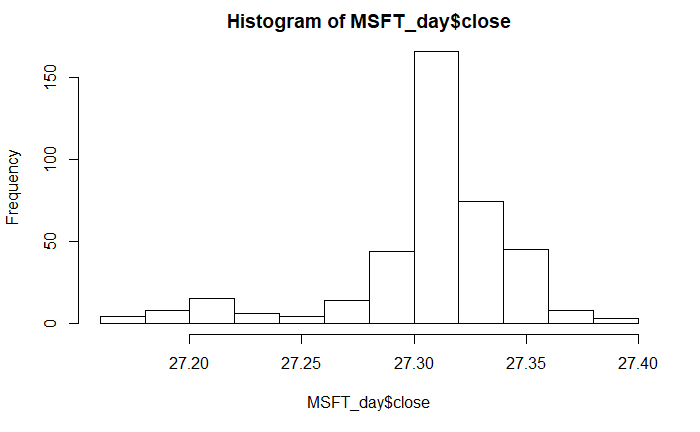

```r
hist(MSFT_day$close)
```

```r
str(MSFT_day)
```

```
'data.frame':   391 obs. of  10 variables:
 $ X         : Factor w/ 1 level "MSFT": 1 1 1 1 1 1 1 1 1 1 ...
 $ Time      : int  930 931 932 933 934 935 936 937 938 939 ...
 $ open      : num  27.1 27.2 27.2 27.2 27.2 ...
 $ close     : num  27.2 27.2 27.2 27.2 27.2 ...
 $ low       : num  27.1 27.1 27.1 27.2 27.2 ...
 $ high      : num  27.2 27.2 27.2 27.2 27.2 ...
 $ Vol.trades: int  754229 328597 343711 231715 151506 169217 223728 64639 109948 338107 ...
 $ Nr.trades : int  764 471 390 339 269 195 261 152 212 410 ...
 $ Average   : num  27.1 27.2 27.2 27.2 27.2 ...
 $ X.1       : int  5 2 3 2 0 2 2 0 0 3 ...
```

```r
names(MSFT_day)
```

```
 [1] "X"          "Time"       "open"       "close"      "low"        "high"       "Vol.trades"
 [8] "Nr.trades"  "Average"    "X.1"
```

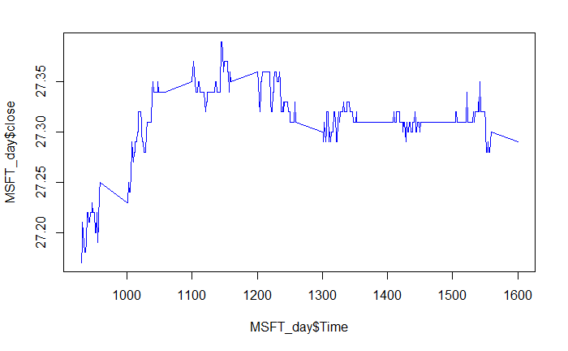

```r
plot(MSFT_day$close, type="l", x = MSFT_day$Time, col="blue")
```

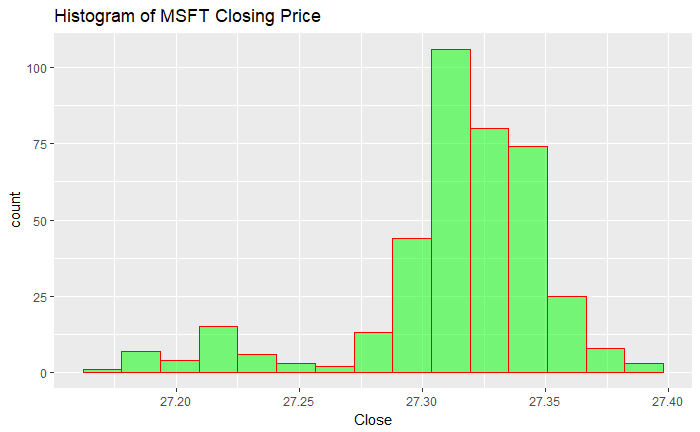

```r
# Advance EDA
qplot(MSFT_day$close, fill = I("green"), alpha = I(.5), col= I("red"),xlab = "Close",  main="Histogram of MSFT Closing Price", bins = 15)
```

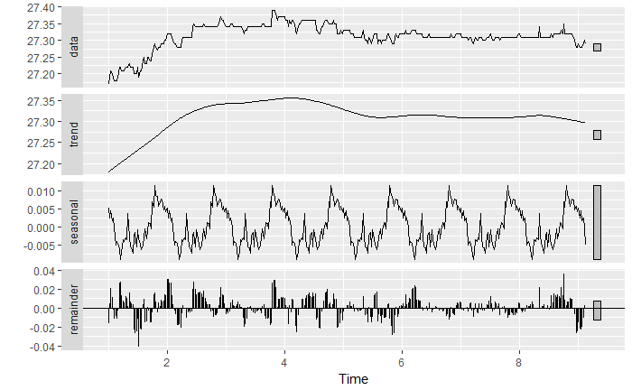

```r
msftminutes = ts(MSFT_day$close, frequency = 48)
autoplot(stl(msftminutes, s.window = "periodic"), ts.colour = "blue")
```

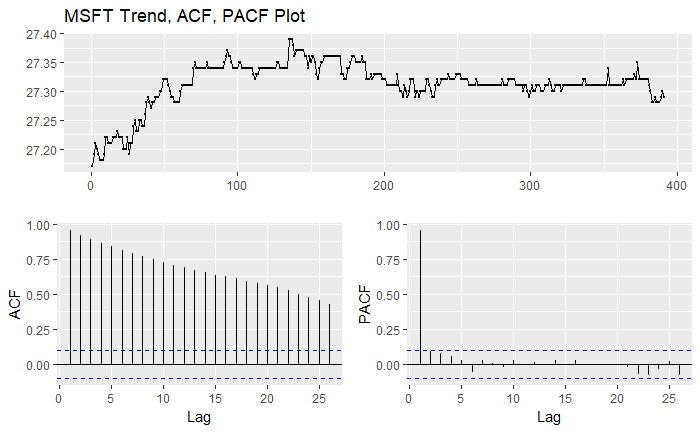

```r
ggtsdisplay(MSFT_day$close, main= "MSFT Trend, ACF, PACF Plot")
```

Advance EDA For Minutes Returns for MSFT

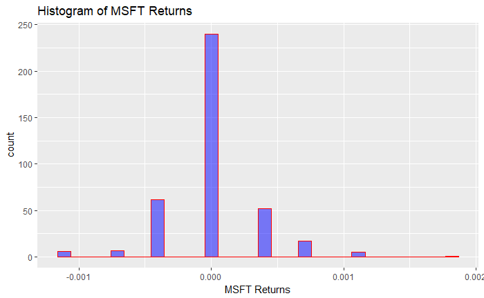

```r
MSFT_price = MSFT_day$close
MSFTreturns =diff(MSFT_price)/MSFT_price[-length(MSFT_price)]
qplot(MSFTreturns, fill = I("blue"), alpha = I(.5), col= I("red"),xlab = "MSFT Returns",  main="Histogram of MSFT Returns", bins = 30)
```

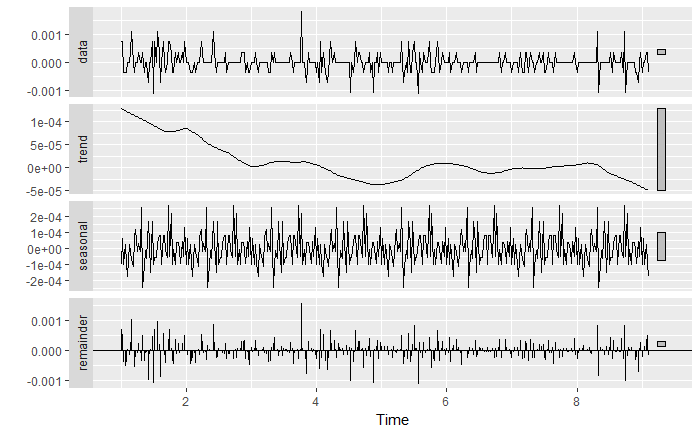

```r
MSFT_returns = ts(MSFTreturns, frequency = 48)
autoplot(stl(MSFT_returns, s.window = 'periodic'), ts.colour = 'blue')
```

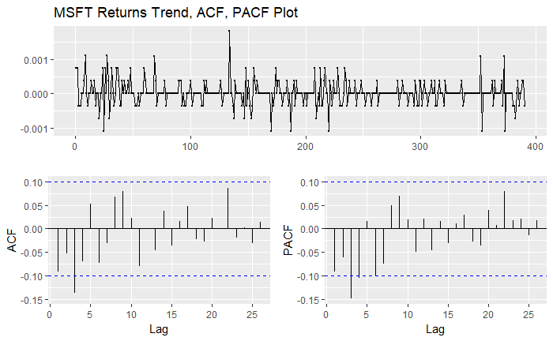

```r
ggtsdisplay(MSFTreturns, main = "MSFT Returns Trend, ACF, PACF Plot")
```

Transformations and EDA - LOG Returns of MSFT

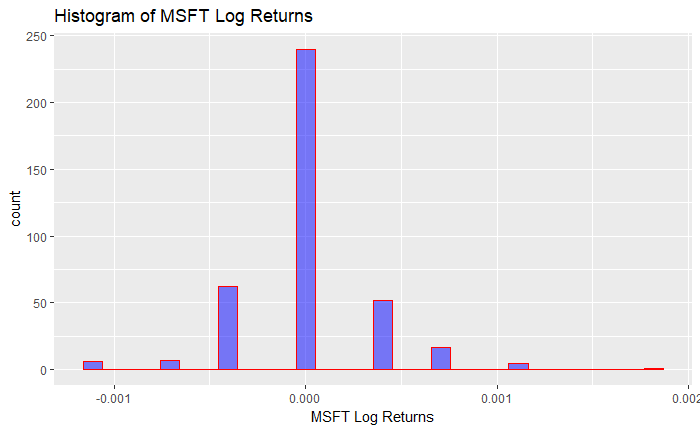

```r
MSFT_logreturns1=diff(log(MSFT_day$close))
qplot(MSFT_logreturns1, fill = I("blue"), alpha = I(.5), col= I("red"),xlab = "MSFT Log Returns",  main="Histogram of MSFT Log Returns", bins = 30)
```

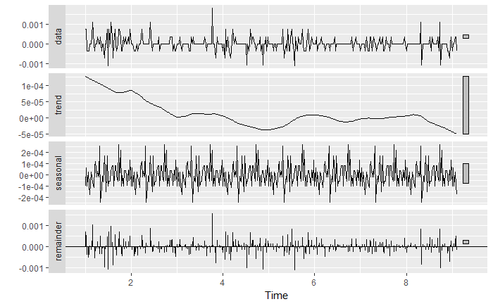

```r
MSFT_logreturns2 = ts(MSFT_logreturns1, frequency = 48)
autoplot(stl(MSFT_logreturns2, s.window = 'periodic'), ts.colour = 'blue')
```

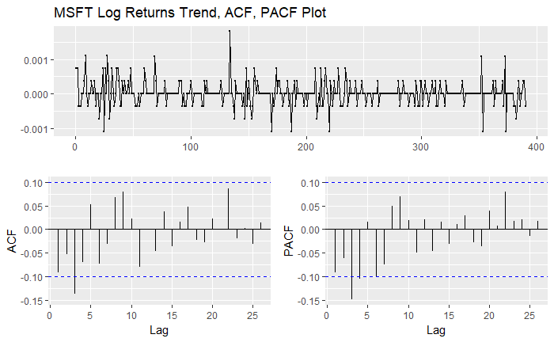

```r
ggtsdisplay(MSFT_logreturns1, main = "MSFT Log Returns Trend, ACF, PACF Plot")
```

Compare Histogram of minute returns and Log returns

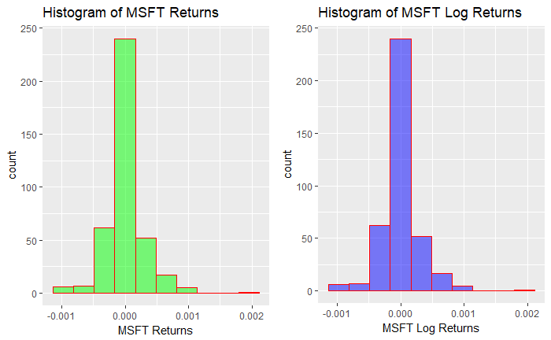

```r
require(gridExtra)
Minute_Returns = qplot(MSFTreturns, fill = I("green"), alpha = I(.5), col= I("red"),xlab = "MSFT Returns",  main="Histogram of MSFT Returns", bins = 10)
Log_Returns=qplot(MSFT_logreturns1, fill = I("blue"), alpha = I(.5), col= I("red"),xlab = "MSFT Log Returns",  main="Histogram of MSFT Log Returns", bins = 10)
grid.arrange(Minute_Returns, Log_Returns, ncol=2)
```

Check Stats of the data

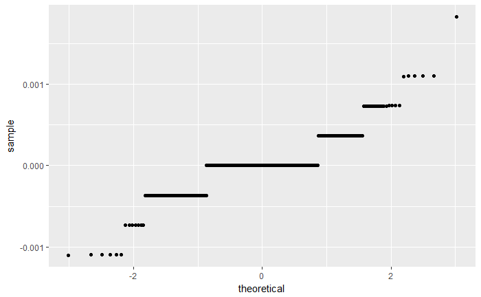

```r
ggplot(data.frame(MSFT_logreturns1), aes(sample=MSFT_logreturns1))+stat_qq()
```

```r
t.test(MSFT_logreturns1)
```

```
    One Sample t-test

data:  MSFT_logreturns1
t = 0.65789, df = 389, p-value = 0.511
alternative hypothesis: true mean is not equal to 0
95 percent confidence interval:
 -2.246933e-05  4.506888e-05
sample estimates:
   mean of x
1.129977e-05
```

```r
library(fBasics) ## This loads the package fBasic
basicStats(MSFTreturns)
```

|  | MSFTreturns |
| --- | --- |
| nobs | 390.000000 |
| NAs | 0.000000 |
| Minimum | -0.001102 |
| Maximum | 0.001829 |
| 1. Quartile | 0.000000 |
| 3. Quartile | 0.000000 |
| Mean | 0.000011 |
| Median | 0.000000 |
| Sum | 0.004429 |
| SE Mean | 0.000017 |

[output cut: 6 more lines]

```r
basicStats(MSFT_logreturns1)
```

|  | MSFT_logreturns1 |
| --- | --- |
| nobs | 390.000000 |
| NAs | 0.000000 |
| Minimum | -0.001103 |
| Maximum | 0.001827 |
| 1. Quartile | 0.000000 |
| 3. Quartile | 0.000000 |
| Mean | 0.000011 |
| Median | 0.000000 |
| Sum | 0.004407 |
| SE Mean | 0.000017 |

[output cut: 6 more lines]

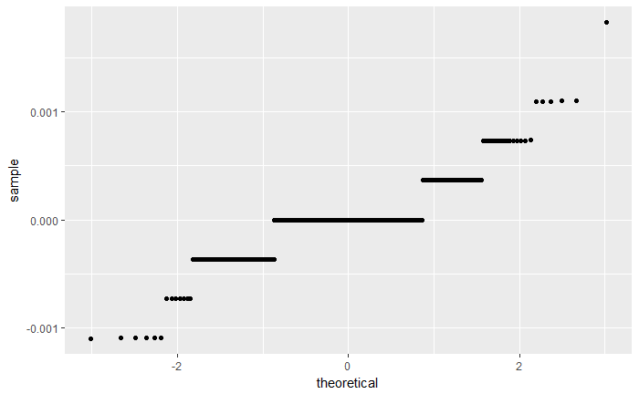

```r
ggplot(data.frame(MSFTreturns), aes(sample=MSFTreturns))+stat_qq()
```

```r
t.test(MSFTreturns)
```

```
    One Sample t-test

data:  MSFTreturns
t = 0.66117, df = 389, p-value = 0.5089
alternative hypothesis: true mean is not equal to 0
95 percent confidence interval:
 -2.241481e-05  4.512925e-05
sample estimates:
   mean of x
1.135722e-05
```

```r
## Normality tests
normalTest(MSFTreturns,method="jb")
```

```
Title:
 Jarque - Bera Normalality Test

Test Results:
  STATISTIC:
    X-squared: 270.6437
  P VALUE:
    Asymptotic p Value: < 2.2e-16

Description:
 Wed May 02 02:35:06 2018 by user: Jai Katariya
```

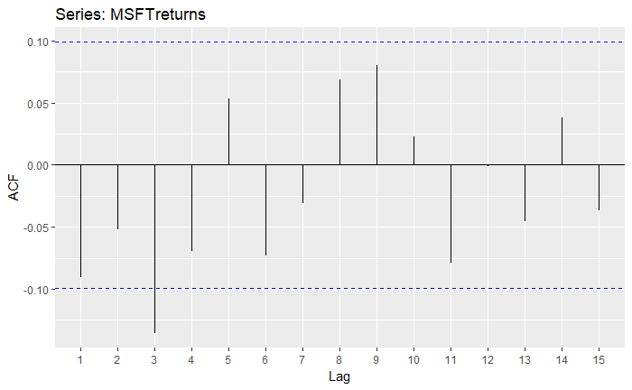

```r
autoplot(acf(MSFTreturns,lag=15, plot = FALSE))
```

```r
#Independence test
Box.test(MSFTreturns,lag=10)
```

```
    Box-Pierce test

data:  MSFTreturns
X-squared = 21.415, df = 10, p-value = 0.01838
```

```r
Box.test(MSFTreturns,lag=10,type="Ljung")
```

```
    Box-Ljung test

data:  MSFTreturns
X-squared = 21.771, df = 10, p-value = 0.01632
```

Model Building

```r
model1=ar(MSFTreturns,method='mle')
model1
```

```
Call:
ar(x = MSFTreturns, method = "mle")

Coefficients:
      1        2        3        4        5        6        7
-0.1262  -0.0930  -0.1866  -0.1256  -0.0016  -0.1112  -0.0764

Order selected 7  sigma^2 estimated as  1.078e-07
```

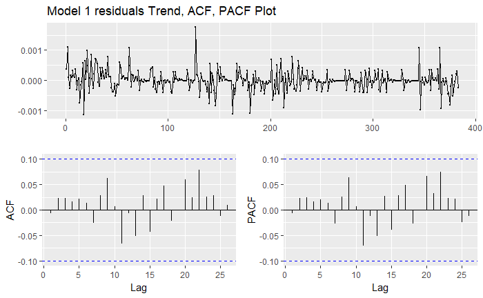

```r
model1_residuals = model1$resid[!is.na(model1$resid)]
ggtsdisplay(model1_residuals, main = "Model 1 residuals Trend, ACF, PACF Plot")
```

```r
#p value is greater than alpha so residuals are independent
Box.test(model1_residuals,lag=10,type='Ljung')
```

```
    Box-Ljung test

data:  model1_residuals
X-squared = 2.923, df = 10, p-value = 0.9832
```

Other models

```r
model2=arima(MSFTreturns,order=c(4,0,3))
model2
```

```
Call:
arima(x = MSFTreturns, order = c(4, 0, 3))

Coefficients:
         ar1      ar2     ar3     ar4      ma1     ma2      ma3  intercept
      0.4105  -0.6668  0.3739  0.0188  -0.5317  0.6439  -0.5958      0e+00
s.e.  0.2305   0.1720  0.1583  0.0788   0.2250  0.1631   0.1397      1e-04

sigma^2 estimated as 1.08e-07:  log likelihood = 2574.5,  aic = -5131
```

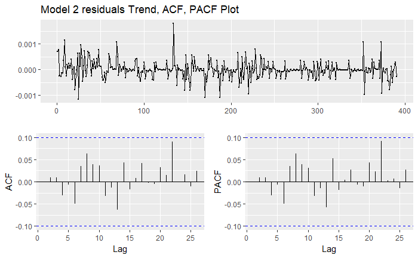

```r
ggtsdisplay(model2$residuals, main = "Model 2 residuals Trend, ACF, PACF Plot")
```

```r
#p value greater than alpha so the residuals are independent
Box.test(model2$residuals,lag=10,type='Ljung')
```

```
    Box-Ljung test

data:  model2$residuals
X-squared = 4.6688, df = 10, p-value = 0.9122
```

```r
model3=arima(MSFTreturns,order=c(3,0,4))
model3
```

```
Call:
arima(x = MSFTreturns, order = c(3, 0, 4))

Coefficients:
         ar1      ar2     ar3      ma1     ma2      ma3     ma4  intercept
      0.4222  -0.6783  0.3882  -0.5427  0.6548  -0.6093  0.0182      0e+00
s.e.  0.3611   0.1800  0.2223   0.3626  0.1973   0.2087  0.1112      1e-04

sigma^2 estimated as 1.08e-07:  log likelihood = 2574.49,  aic = -5130.99
```

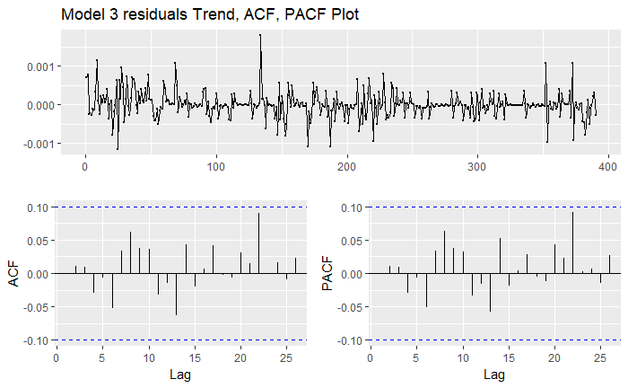

```r
ggtsdisplay(model3$residuals, main = "Model 3 residuals Trend, ACF, PACF Plot")
```

```r
#p value greater than alpha so the residuals are independent
Box.test(model3$residuals,lag=10,type='Ljung')
```

```
    Box-Ljung test

data:  model3$residuals
X-squared = 4.6003, df = 10, p-value = 0.9162
```

```r
#p value greater than alpha so the residuals are independent
model4=arima(MSFTreturns,order=c(3,0,3))
model4
```

```
Call:
arima(x = MSFTreturns, order = c(3, 0, 3))

Coefficients:
         ar1      ar2     ar3      ma1     ma2      ma3  intercept
      0.3739  -0.6744  0.3638  -0.4925  0.6407  -0.5845      0e+00
s.e.  0.1786   0.1755  0.1633   0.1598  0.1674   0.1415      1e-04

sigma^2 estimated as 1.08e-07:  log likelihood = 2574.47,  aic = -5132.95
```

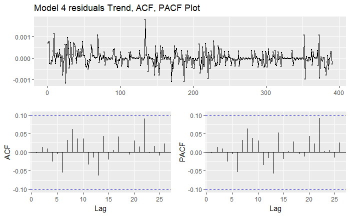

```r
ggtsdisplay(model4$residuals, main = "Model 4 residuals Trend, ACF, PACF Plot")
```

```r
Box.test(model4$residuals,lag=10,type='Ljung')
```

```
    Box-Ljung test

data:  model4$residuals
X-squared = 4.5546, df = 10, p-value = 0.9189
```

```r
model5=arima(MSFTreturns,order=c(6,0,6))
```

```
possible convergence problem: optim gave code = 1
```

```r
model5
```

```
Call:
arima(x = MSFTreturns, order = c(6, 0, 6))

Coefficients:
         ar1      ar2      ar3     ar4      ar5     ar6      ma1     ma2     ma3      ma4     ma5
      0.4900  -0.5957  -0.6348  0.4472  -0.7563  0.2438  -0.6142  0.5982  0.4341  -0.5315  0.7299
s.e.  0.2008   0.1763   0.1514  0.1859   0.1753  0.1641   0.1866  0.1738  0.1388   0.1750  0.1684
          ma6  intercept
      -0.4909      0e+00
s.e.   0.1398      1e-04

sigma^2 estimated as 1.049e-07:  log likelihood = 2579.54,  aic = -5131.08
```

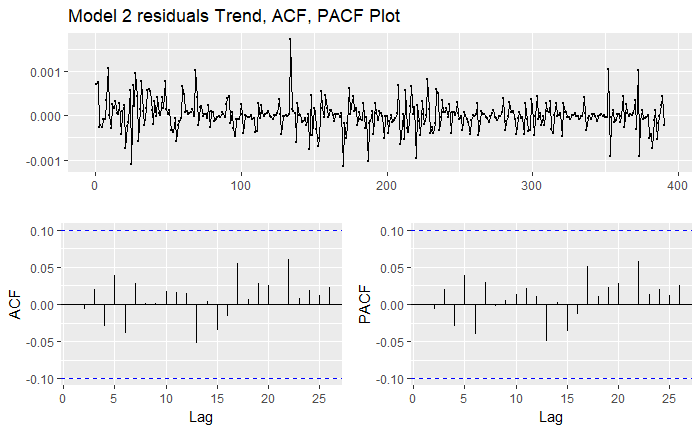

```r
ggtsdisplay(model5$residuals, main = "Model 2 residuals Trend, ACF, PACF Plot")
```

```r
Box.test(model5$residuals,lag=10,type='Ljung')
```

```
    Box-Ljung test

data:  model5$residuals
X-squared = 2.1449, df = 10, p-value = 0.9951
```

We select Model 4

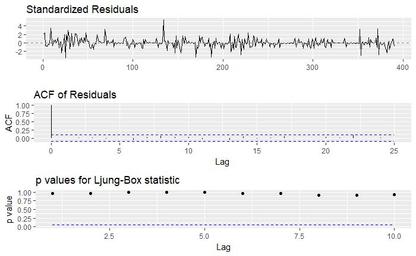

```r
ggtsdiag(model4)
```

```r
poly1=c(1,-model4$coef[1:3])
roots=polyroot(poly1)
roots
```

```
[1] -0.082622+1.163864i -0.082622-1.163864i  2.018890-0.000000i
```

```r
Mod(roots)
```

```
[1] 1.166793 1.166793 2.018890
```

```r
prediction = predict(model4, 10)
prediction
```

```
$pred
Time Series:
Start = 391
End = 400
Frequency = 1
 [1] -4.556956e-05  2.140584e-05  7.631031e-05  7.302384e-06 -3.116336e-05  2.096842e-05
 [7]  4.129743e-05 -2.540676e-07 -1.053503e-05  2.103968e-05

$se
Time Series:
Start = 391
End = 400
Frequency = 1
 [1] 0.0003286605 0.0003309622 0.0003319559 0.0003366178 0.0003370852 0.0003377816 0.0003377817
 [8] 0.0003384441 0.0003384442 0.0003387435
```